# 10 Black Box Fidelity Improvements

- Show All Code
- Hide All Code
- View Source

## 10.1 The Modular Nature of BLISS

One of BLISS’s most significant architectural advantages is its **modularity**: each black box can be replaced, upgraded, or subdivided without changing the BLISS framework itself. The system optimizer interacts with each BB only through the RS models — the polynomial surrogates — not with the disciplinary codes directly. This means that upgrading the aerodynamics BB from a drag polar model to a full Reynolds-averaged Navier-Stokes solver requires only that:

1. The new BB accepts the same set of system-level inputs $Z$ and produces the same coupling outputs $Y^A$.
2. The local optimization within the BB is reformulated to account for the new analysis.

The RS fitting and system optimization layers remain unchanged. This property makes BLISS an ideal framework for progressive design refinement, where early conceptual studies use inexpensive surrogate BBs and later detailed design phases substitute high-fidelity analyses.

## 10.2 Improved Aerodynamics Black Box: CFD Integration

Altus (2002) described an upgrade to the aerodynamics BB in which the AWAVE wave-drag model is replaced by the **CFL3D** Reynolds-averaged Navier-Stokes solver, version 6.0, developed at NASA Langley Research Center’s Computational Fluids Laboratory [1].

CFL3D solves the time-dependent conservation-law form of the RANS equations using:

- Semi-discrete finite volume spatial discretization
- Upwind biasing for convective and pressure terms
- Central differencing for shear stress and heat transfer
- Implicit time advancement (LU-SSOR and GMRES variants)
- Multiple turbulence models (0-, 1-, 2-equation)
- Multi-block topology with 1-to-1 blocking, patching, and overset grids

The key challenge in integrating CFL3D with BLISS-RS is that each DOE sample point represents a *different aircraft geometry* — a different combination of wing sweep, thickness, aspect ratio, etc. A full-aircraft structured grid cannot be regenerated quickly for each design point.

### 10.2.1 Grid Morphing with MASSOUD

The solution adopted in Altus (2002) was the **MASSOUD** (Multidisciplinary Aero/Struc Shape Optimization Using Deformation) algorithm [2]. MASSOUD is a geometry parameterization tool that uses soft-object animation algorithms from computer graphics to deform an existing surface and volume grid to a new geometry without full grid regeneration.

MASSOUD parameterizes geometric perturbations rather than the geometry itself. Shape design variables such as thickness, camber, twist, shear, and planform are mapped to grid deformation fields. The key advantages are:

- Grid topology is preserved: no re-blocking or re-meshing is required.
- Sensitivity derivatives are available analytically.
- Compatible with a wide range of CFD and CSM solvers.
- Both low-fidelity (linear aerodynamics) and high-fidelity (nonlinear CFD) analyses can use the same parameterization.

Figure 10.1 shows the upgraded aerodynamics black box data flow with CFL3D and MASSOUD.

```
flowchart TD
    IN["**Z-variables (inputs)**\nt/c · AR_w · Λ_w · S_w · λ · θ_w · dA · dB"]

    IN --> MW & MT

    subgraph morph ["  MASSOUD grid morphing  "]
        direction LR
        MW["Wing\nmorphing"]
        MT["Tail\nmorphing"]
    end

    MW & MT --> GS["Grid Splice\nwing + tail + fuselage"]
    GS --> CFD["**CFL3D**\nRANS Solver"]
    CFD --> POST["CFL3D Post-processor"]
    POST --> OUT["**Outputs**\nL · D · β(1:6) · L_HT · L_w"]

    classDef io    fill:#f1f5f9,stroke:#64748b,stroke-width:1.5px,color:#0f172a
    classDef morph fill:#dbeafe,stroke:#3b82f6,stroke-width:1.5px,color:#1e3a5f
    classDef util  fill:#fefce8,stroke:#ca8a04,stroke-width:1.5px,color:#422006
    classDef cfd   fill:#dcfce7,stroke:#16a34a,stroke-width:2px,color:#14532d

    class IN,OUT io
    class MW,MT morph
    class GS,POST util
    class CFD cfd
```

Figure 10.1: Upgraded aerodynamics black box incorporating CFL3D RANS solver and MASSOUD grid morphing. From BLISS-RS’s perspective the BB remains a function (Z, Y*) → (L, D, β), but the inner analysis is now full Navier-Stokes. Reproduced from Altus (2002) Fig. 46.

### 10.2.2 Improved Lift Distribution

In the original BLISS-98 aerodynamics model, the spanwise lift distribution was approximated using the Shrenk method (Chapter 2). In the upgraded BB, CFL3D provides the actual pressure distribution, and the spanwise lift $L(y)$ is passed to the structures BB as six polynomial coefficients $\beta_1, \ldots, \beta_6$:

$$L(y) \approx \sum_{k=1}^{6} \beta_k P_k(y)
\tag{10.1}$$

where $P_k(y)$ are basis polynomials (e.g., Legendre polynomials on the semi-span). This representation is far more accurate than the Shrenk approximation, particularly near the wing tip where tip vortex effects cause departures from elliptical distributions at transonic and supersonic speeds.

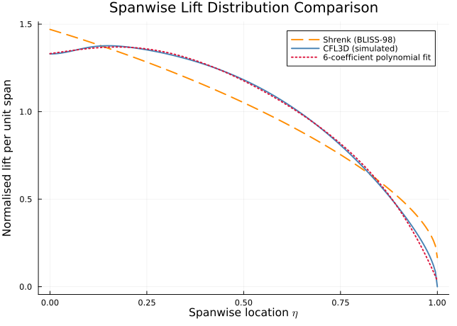

Figure 10.2: Spanwise lift distribution comparison. The Shrenk approximation (used in BLISS-98) provides a smooth estimate, but the 6-coefficient polynomial can represent the CFL3D computed distribution, including wing-body junction effects and tip roll-off.

```julia
η = range(0.0, 1.0, length=200)

# Shrenk (from Chapter 2)
ℓ_shrenk(η) = 0.5 * ((4/π)*sqrt(max(1 - η^2, 0.0)) + 2*(1-0.8η)/(1+0.2))

# Simulated CFL3D-like distribution (with junction and tip effects)
ℓ_cfd(η) = 1.4 * sqrt(max(1 - η^2, 0.0)) * (1.0 - 0.4*η^4) * (1.0 - 0.05*exp(-(η/0.1)^2))

# 6-coefficient polynomial fit to the CFL3D distribution
η_sample = range(0.0, 1.0, length=30)
y_sample  = ℓ_cfd.(η_sample)
X_poly    = hcat([η_sample.^k for k in 0:5]...)
β         = X_poly \ y_sample
ℓ_poly(η) = sum(β[k+1] * η^k for k in 0:5)

p = plot(η, ℓ_shrenk.(η), lw=2, color=:darkorange, linestyle=:dash,
         label="Shrenk (BLISS-98)", xlabel=L"Spanwise location $\eta$",
         ylabel="Normalised lift per unit span",
         title="Spanwise Lift Distribution Comparison")
plot!(η, ℓ_cfd.(η), lw=2, color=:steelblue, label="CFL3D (simulated)")
plot!(η, ℓ_poly.(η), lw=2, color=:crimson, linestyle=:dot,
      label="6-coefficient polynomial fit")

p
```

## 10.3 Improved Structures Black Box: Flutter Constraint

The original BLISS-98 structures BB used stress and deflection constraints only. The upgraded structures BB in Altus (2002) adds an **anti-flutter constraint** based on the ratio of the deformed wing root bending moment $M_{DR}$ to the rigid wing root bending moment $M_{RR}$:

$$\text{Flutter constraint:} \quad \frac{M_{DR}}{M_{RR}} \leq 1.0
\tag{10.2}$$

When the deformed wing experiences aerodynamic moments that exceed the rigid wing’s stabilizing moments, flutter onset occurs. The constraint $M_{DR}/M_{RR} \leq 1$ provides a first-order approximation to the aeroelastic stability boundary computable within the ELAPS framework (see Appendix B for the full derivation).

The displacement variables used to enforce this constraint are $d_A$ (vertical displacement at the wing tip leading edge, in) and $d_B$ (vertical displacement at the wing tip trailing edge, in), which replace the scalar “twist” $\Omega$ variable used in BLISS-98.

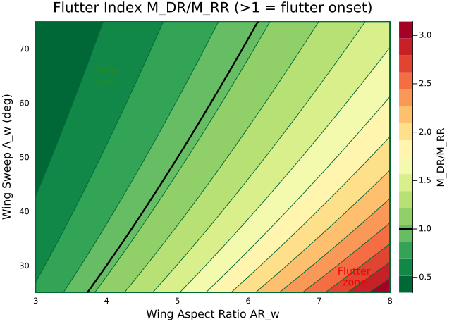

Figure 10.3: Flutter constraint sensitivity to wing aspect ratio and sweep angle at fixed thickness ratio. High aspect ratio combined with low sweep produces the most flutter-critical configurations. Adding this constraint to BLISS-RS prevents the optimizer from finding high-span, low-sweep designs that are aerodynamically efficient but structurally dangerous.

```julia
# Simplified flutter index model (MDR/MRR):
# Flutter index increases with AR (more flexible) and decreases with Λ (stiffer swept wing)
flutter_index(AR, Λ_deg) = (AR / 4.0)^1.5 / (1 + 0.02 * (Λ_deg - 30))

AR_range  = range(3.0, 8.0, length=50)
Λ_range   = range(25.0, 75.0, length=50)
FI_grid   = [flutter_index(ar, λ) for λ in Λ_range, ar in AR_range]

contourf(AR_range, Λ_range, FI_grid,
         xlabel="Wing Aspect Ratio AR_w",
         ylabel="Wing Sweep Λ_w (deg)",
         title="Flutter Index M_DR/M_RR (>1 = flutter onset)",
         colorbar_title="M_DR/M_RR",
         color=cgrad(:RdYlGn, rev=true), levels=15)
contour!(AR_range, Λ_range, FI_grid, levels=[1.0],
         color=:black, lw=2.5, linecolor=:black, label="Flutter boundary")
annotate!(7.5, 28.0, text("Flutter\nzone", 10, :red2))
annotate!(4.0, 65.0, text("Safe\nzone", 10, :forestgreen))
```

## 10.4 Impact on System Data Flow

The upgraded aerodynamics and structures BBs alter the coupling variable set, as shown in Figure 10.4. The key changes are:

1. The scalar “twist” $\Omega$ is replaced by two displacement variables $(d_A, d_B)$ that carry richer aeroelastic information to the structures BB.
2. The six-coefficient lift distribution $\beta(1:6)$ replaces the scalar lift $L$ as the coupling from aerodynamics to structures, allowing the structures BB to compute loads more accurately along the span.
3. The flutter constraint is enforced within the structures BB local optimization.

```
flowchart LR
    SysOpt(["**System Optimizer**\nZ · Y* · w"])

    subgraph discs ["  Disciplinary Black Boxes  "]
        S["**Structures BB**\nELAPS + Flutter constraint"]
        A["**Aero BB**\nCFL3D + MASSOUD"]
        P["**Power BB**\nEngine deck"]
    end

    Perf[/"**Performance BB**\nBreguet Range"/]

    SysOpt -- "Z: t/c, AR, Λ,\nS, λ, θ_w" --> S & A & P

    A -- "β(1:6), dA, dB" --> S
    S -- "W_T, dA, dB" --> A
    A -- "D" --> P
    P -- "SFC, W_E, ESF" --> A

    S -- "W_F" --> Perf
    A -- "L/D" --> Perf
    P -- "SFC" --> Perf
    Perf -- "Range" --> SysOpt

    classDef sysopt fill:#ede9fe,stroke:#7c3aed,stroke-width:2px,color:#2e1065
    classDef struct fill:#dbeafe,stroke:#3b82f6,stroke-width:1.5px,color:#1e3a5f
    classDef aero   fill:#dcfce7,stroke:#16a34a,stroke-width:1.5px,color:#14532d
    classDef power  fill:#fefce8,stroke:#ca8a04,stroke-width:1.5px,color:#422006
    classDef perf   fill:#fff1f2,stroke:#e11d48,stroke-width:1.5px,color:#4c0519

    class SysOpt sysopt
    class S struct
    class A aero
    class P power
    class Perf perf
```

Figure 10.4: Updated BLISS-RS system data flow for the high-fidelity BBs. Coupling variables dA, dB, and β(1:6) replace the scalar twist Ω, carrying richer aeroelastic information between disciplines. Reproduced from Altus (2002) Fig. 48.

## 10.5 Implications for BLISS-RS

The fidelity upgrades described in this chapter illustrate a key principle: **BLISS-RS scales gracefully from conceptual to detailed design**. The algorithm’s structure remains identical whether the BBs are simple analytical surrogates or full-scale RANS + FEM analyses. The cost scaling is:

$$T_{\text{total}} \approx N_{\text{iter}} \times T_{\text{BB,max}} \times N_S
\tag{10.3}$$

[1]

NASA Langley Research Center, “CFL3D Version 6.0 User Manual,” 2000.

[2]

Samareh, J. A., “MASSOUD: A Multidisciplinary Aero/Structural Shape Optimization Using Deformation,” *Proceedings of the 40th AIAA/ASME/ASCE/AHS Structures, Structural Dynamics, and Materials Conference*, 1999.